# Report 2

Barbara Chen

2023-06-06

In this report, I analyzed the differences between search terms (coffee table, nightstand, living room table, etc.) used to gather the data. I also analyzed the differences between products shown on the first and second page of each search term. Lastly, I analyzed the size and color/material of different products.

The goal of this report is to see if there are certain factors or features of a product that are associated with high revenue.

In the previous report, I did not find any relationship between price and sales and price and revenue. However, I found that $90~$160 was a good price range. Thus, for this report, instead of comparing an individual product’s price and revenue, I decided a better approach was to group the products based on price and revenue and compare the groups.

There are 4 revenue groups which are based on the quartiles. The products with revenue in the lower 25% is grouped into q1; 25%~50% is grouped into q2, and so on.

There are 2 price groups. Products with prices below $90 is group 1; $90~$160 is group 2, and the rest is group 3.

## Conclusion

### Search Term:

1. Despite being the most popular search term, ‘coffee table’ has pretty average revenue.
2. ‘Living room table’ and ‘nightstand’ have the highest percentage of products in the higher revenue range.
3. About 30% of the products in ‘living room table’ is above $90, while only about 20% of the products in ‘nightstand’ is above $90.

### Size:

1. ‘Nightstand’, ‘side table’, ‘end table’, ‘bedside table’, and ‘accent table’ tend to be on the smaller side (D+W+H: 40 and 60 inches).
2. ‘Coffee table’ is on the larger side (D+W+H: 70~80 inches).
3. ‘Living room table’ has the widest range of dimension (D+W+H: 50 and 80 inches).
4. ‘Sofa table’ leans the biggest (D+W+H: 80~100 inches).
5. Size had no observable effect on revenue. In general, average girth is around 50~80 inches.

### Pages:

1. In general, the first page of each search term shows more cheaper items than the second page. This is especially true for ‘coffee table’.
2. In general, the first page does not show as many recent products. However, the degree varies according to the search term.
3. The reviews for page 1 and 2 are similar.

## 1 Search Terms

### 1.1 Price

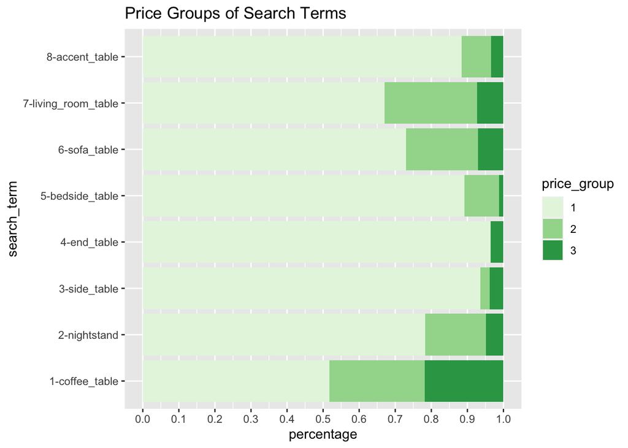

#### Observations

1. For coffee table, about 50% of the products are more than $ 90. It also has the highest percentage (20%) of products above $160.
2. For nightstand, sofa table, and living room table, about 60~80% of the products are less than $90.
3. For the rest, about 90% of the products are less than $90 (cheaper group).

### 1.2 Revenue

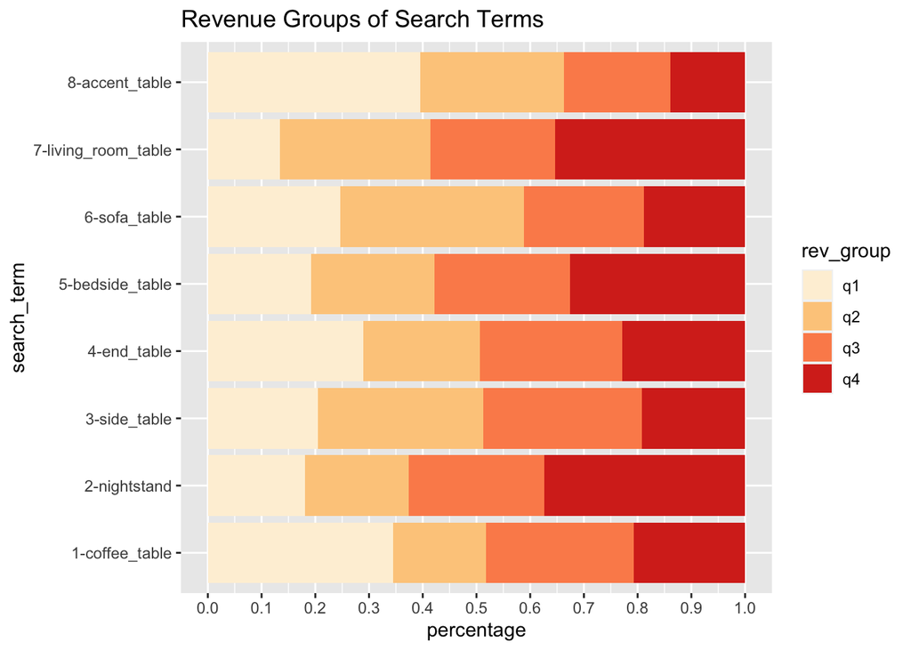

#### Observations

1. Coffee table tends to have higher prices but lower sales and revenue. This is likely due to the fact that about 20% of the products are above $160, which is quite expensive and also generates low revenue.
2. In contrast, living room table which also has slightly higher price distribution does generate higher revenue.
3. Nightstand generates higher revenue overall despite having lower prices.
4. Sub-par revenue (<50% in q3 and q4): sofa table, accent table.
5. On-par revenue (~50% in q3 and q4): coffee table, side table, end table
6. Good revenue (>50% in q3 and q4): nightstand, bedside table, living room table

### 1.3 Product Dimension (Depth, Width, Height)

To measure the general “size” of an item, I used two metrics. The first is depth + width + height, the second is the volume. The reason I did not compare each individual dimension is two-fold. First, one dimension does not capture the overall size of an item Second, the order in which the dimension are given is not consistent across all items.

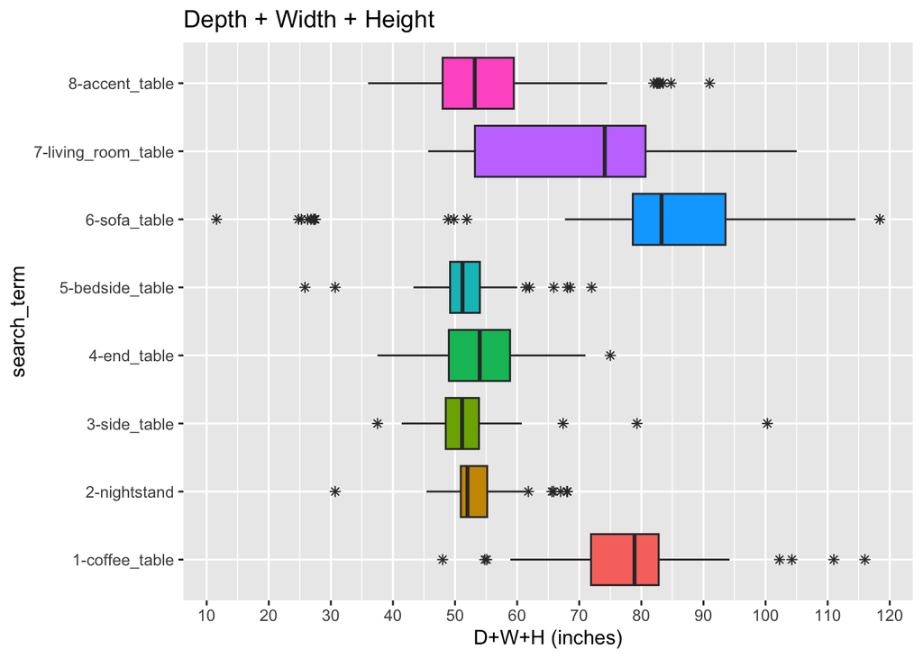

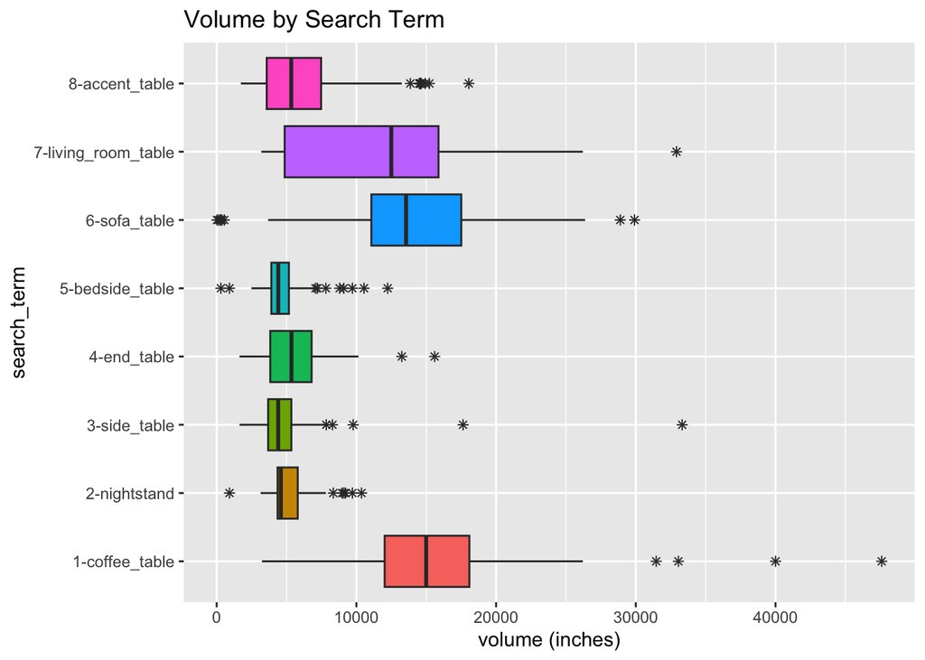

#### Observations

1. Nightstand, side table, end table, beside table, and accent table tend to be on the smaller side.
2. Coffee table, sofa table, and living room table are on the bigger side.
3. For bigger items, go for living room table.
4. For smaller items, go for nightstand, side table or bedside table.
5. Living room table has a pretty wide range of dimensions

## 2. Page Comparisons

The products which are displayed on the first page of the search term generally has higher revenue.

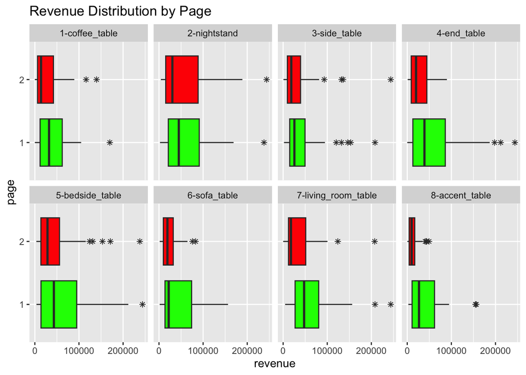

#### Observations

1. Overall, the first page generates higher revenue.
2. Nightstand, which overall generates the high revenue, has similar revenue distribution between page 1 and 2.

So, what are some differences between products on the first and second page?

### 2.1 Price

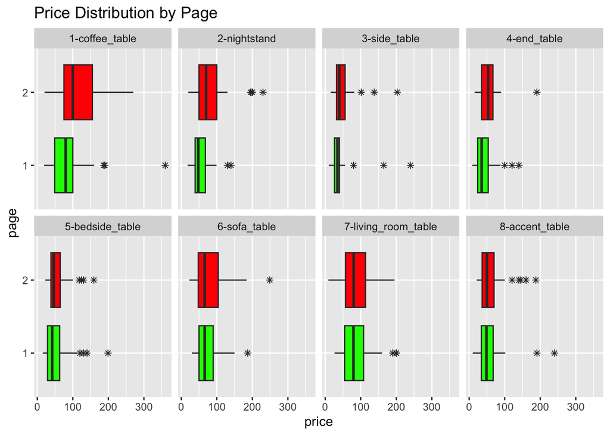

#### Observations

1. For coffee table, nightstand, side table, and end table, the first page shows more cheaper products.
2. For coffee table, only 25% of the items on the first page are over $100, whereas for the second page, 50% are over $100.
3. For living room table, the price on the first and second page are relatively similar. This could explain why despite both having higher price range, living room table still manages to have higher revenue.

### 2.2 Creation Date

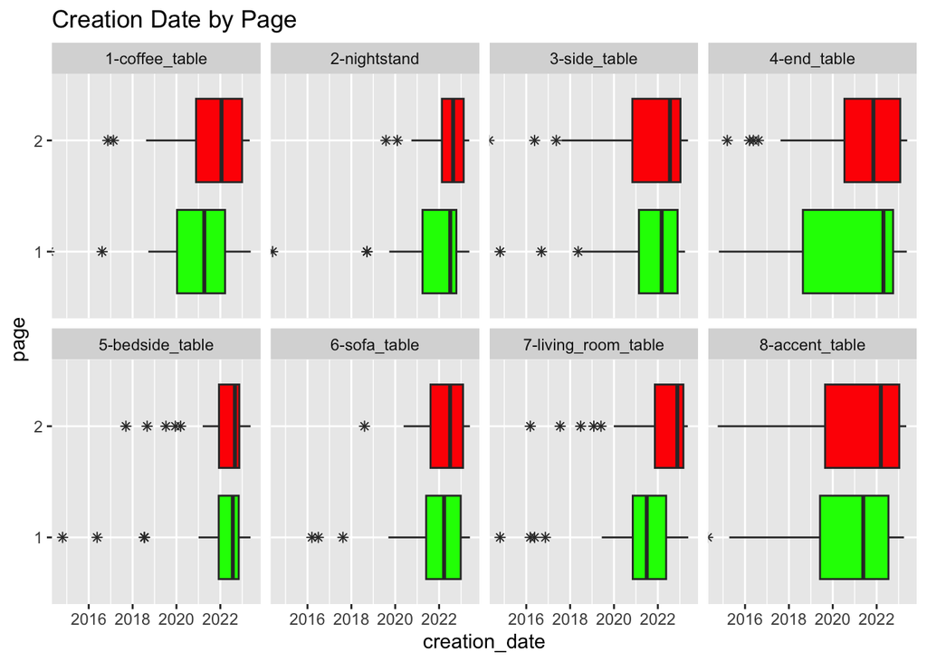

#### Observations

1. The first page doesn’t show as many recent products as the second page, but not by a significant amount.
2. For living room table and coffee table, the second page shows more products which were created after 2022.

### 2.3 Ratings

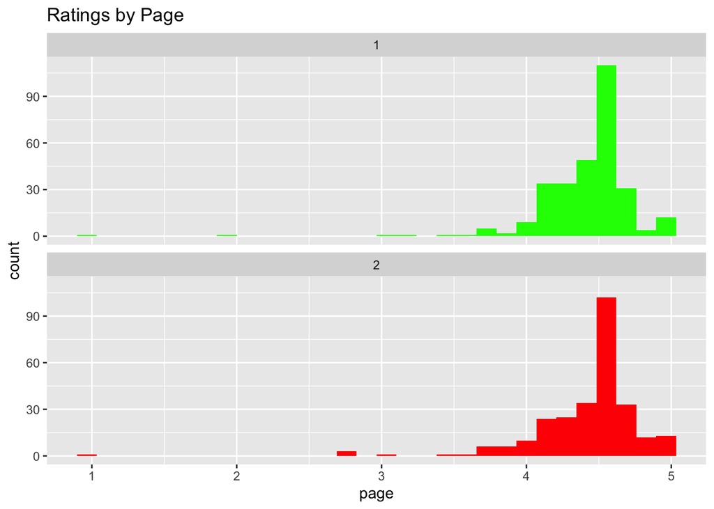

#### Observations

1. Similar ratings distributions.

## 3. Color Group

### 3.1 Distribution

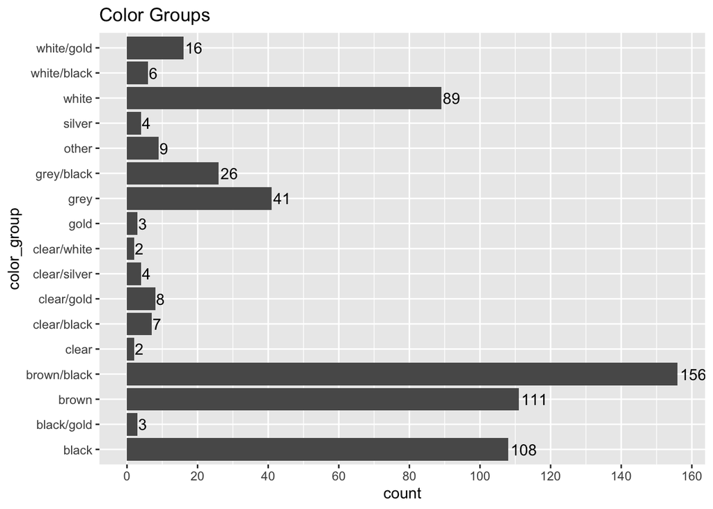

#### Observations

1. Top colors: Brown/black -> brown -> black -> white -> grey -> grey/black (in desc. order of appearance)
2. Top material: brown/black -> wood + metal frame

### 3.2 Revenue

Let’s look at the colors with at least 20 listings. This includes black, brown, brown/black, grey, grey/black, and white.

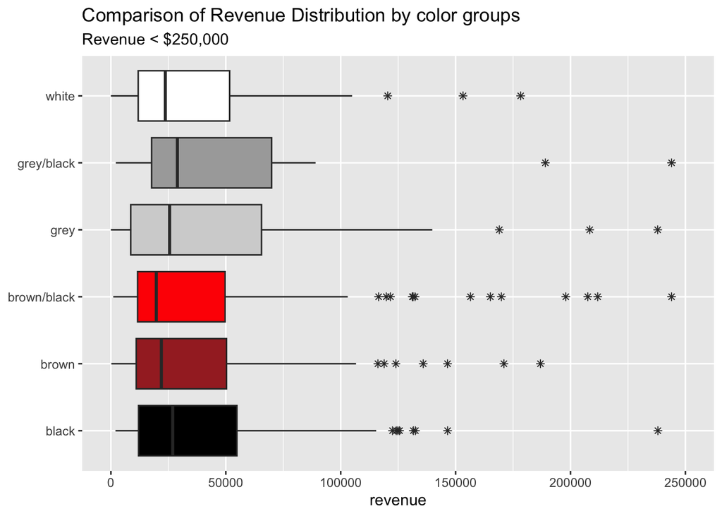

#### Observations

1. Among the most popular items, grey and grey/black generate slightly higher revenue.
2. Despite being the most popular colors, products in the brown and brown/black color group have relatively lower revenue.
3. Grey/grey black have higher revenue.

### 3.3 Search Term

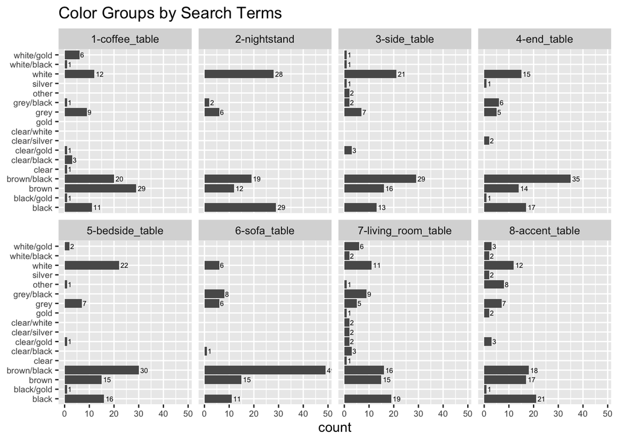

#### Observations

Compared to other search terms, living room table has a diverse range of products of different colors and materials (including plastic, glass, gold, etc.). These products tend to be more pricey but also generate higher revenue.

Color breakdown of each search term. (Some products are duplicated, so ignore the total count for each color group. )

## 4. Revenue Groups

To confirm the findings above, let’s compare the revenue groups.

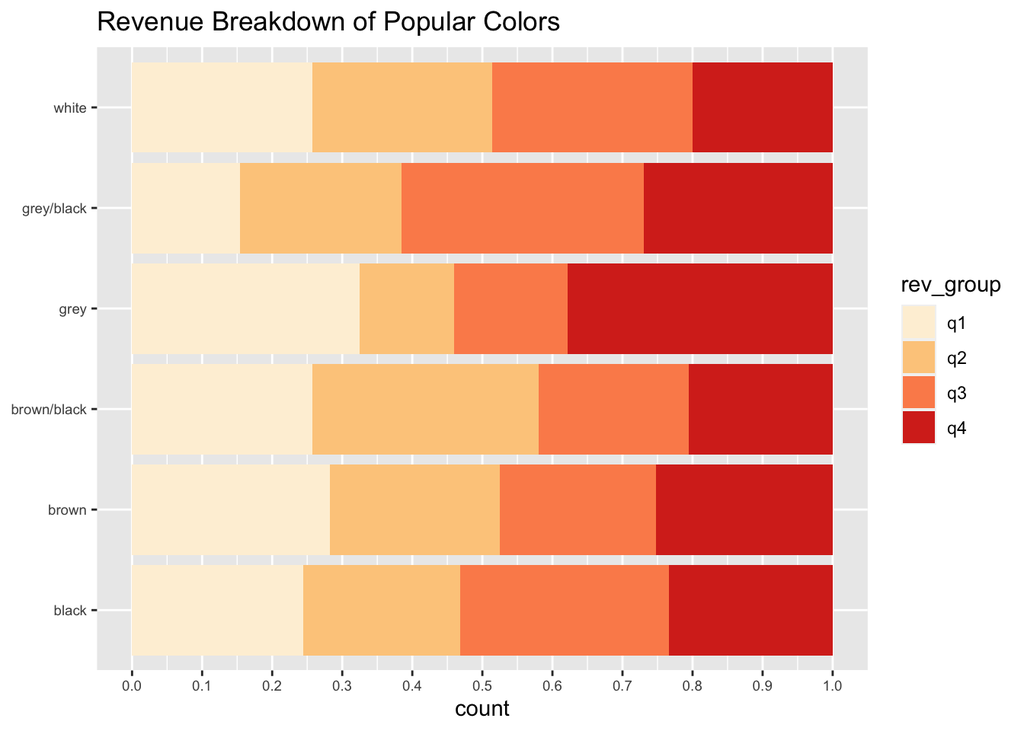

Indeed, while brown/black is the most popular, it is not the best performing color considering it has the more products in q2 than other other revenue groups. In comparison, grey and grey/black has more products in q3 and q4 than other revenue groups. However, it also risky since it has quite a few products in q1.

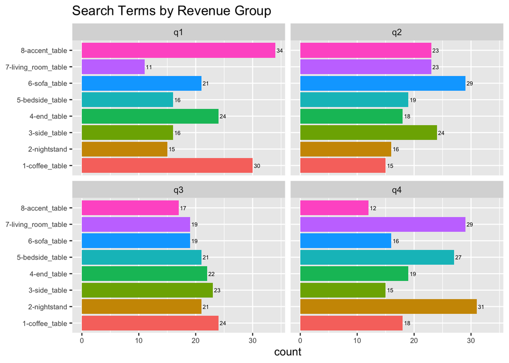

The best performing search terms are ‘nightstand’, ‘bedside table’, and ‘living room table’.

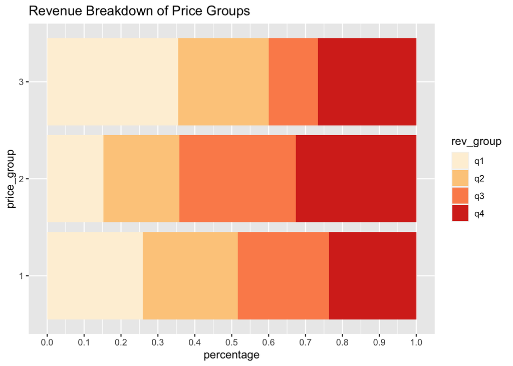

Price group 1 has average performance (almost uniform distribution among all revenue groups). Price group 2 has the best performance with almost 65% of products in q3 and q4 and only 15% of products in q1.

## Misc.

Living room table vs coffee table – They both have similar ratings and size distribution. They both contain more higher priced items. Despite their similarities, coffee table generates low revenue in comparison. Why is that?

```
## [1] "Percentage of 'coffee table' products above $90 shown on page 1: 0.347826086956522"
```

```
## [1] "Percentage of 'living room table' products above $90 shown on page 1: 0.483870967741935"
```